# Project 2

## (d) Compute sample autocorrelation and partial autocorrelation functions for the monthly mortgage rate and explain their meanings. Is there any model suggested by the autocorrelation or partial autocorrelation functions?

The transformation that most effectivly provides stationarity to the time series is growth rate which we calculate by log(x_t) - log(x_t-1). Fig 5 shows what the time series looks like after such transformation along with their theoretcal quantiles. We can also see that morg has a more stebalized variance and their distribution looks less skewed. We now look at the acf and pacf of morg in fig 6. From the plots in fig 6 we can identify the stationarity is precent and there are a few models that could fit this data well. Some of the models to consider are MA(1) based on the significant lag 1, AR(2) based on the two significant lags 1 and 2, and ARIMA(2,0,1).

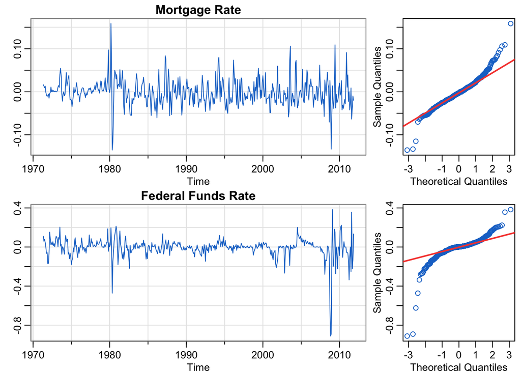

```r
new_morg = log(morg) - log(lag(morg, -1))
new_ffr = log(ffr) - log(lag(ffr, -1))

layout(matrix(1:4,2), widths = c(2.5,1))

tsplot(new_morg, main = "Mortgage Rate", ylab = "",col = 4, margin = 0)
tsplot(new_ffr, main = "Federal Funds Rate", ylab = "",col = 4, margin = 0)

qqnorm(new_morg, main = "", col = 4)
qqline(new_morg, col = 2, lwd = 2)
qqnorm(new_ffr, main = "", col = 4)
qqline(new_ffr, col = 2, lwd = 2)
```

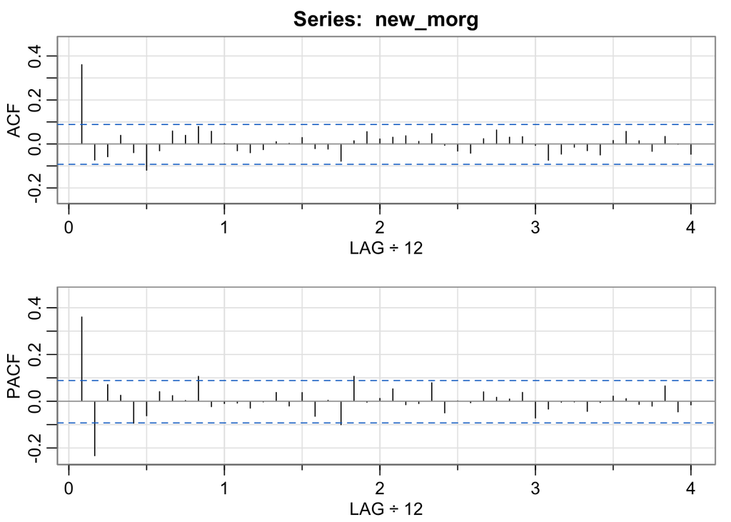

```
##      [,1]  [,2]  [,3] [,4]  [,5]  [,6]  [,7] [,8] [,9] [,10] [,11] [,12] [,13]
## ACF  0.36 -0.07 -0.06 0.04 -0.04 -0.12 -0.03 0.06 0.04  0.08  0.06  0.00 -0.03
## PACF 0.36 -0.23  0.07 0.03 -0.09 -0.06  0.04 0.02 0.00  0.11 -0.02 -0.01 -0.01
##      [,14] [,15] [,16] [,17] [,18] [,19] [,20] [,21] [,22] [,23] [,24] [,25]
## ACF  -0.04 -0.03  0.01  0.00  0.03 -0.02 -0.02 -0.08  0.01  0.06  0.02  0.03
## PACF -0.03  0.00  0.04 -0.02  0.04 -0.06  0.00 -0.10  0.11  0.00  0.01  0.05
##      [,26] [,27] [,28] [,29] [,30] [,31] [,32] [,33] [,34] [,35] [,36] [,37]
## ACF   0.04  0.01  0.05 -0.01 -0.03 -0.04  0.02  0.06  0.03  0.03 -0.01 -0.07
## PACF -0.01 -0.01  0.08 -0.05  0.00 -0.01  0.04  0.02  0.01  0.04 -0.07 -0.03
##      [,38] [,39] [,40] [,41] [,42] [,43] [,44] [,45] [,46] [,47] [,48]
## ACF  -0.05 -0.01 -0.03 -0.05  0.02  0.06  0.01 -0.03  0.03  0.00 -0.05
## PACF  0.00  0.00 -0.04 -0.01  0.02  0.01 -0.01 -0.02  0.07 -0.05 -0.02
```

```r
acf2(new_morg)
```

5. Build an ARIMA model for the monthly mortgage rate. Perform model checking and write down the fitted model. If there are competing models that fit the data, determine your model selection criterion.

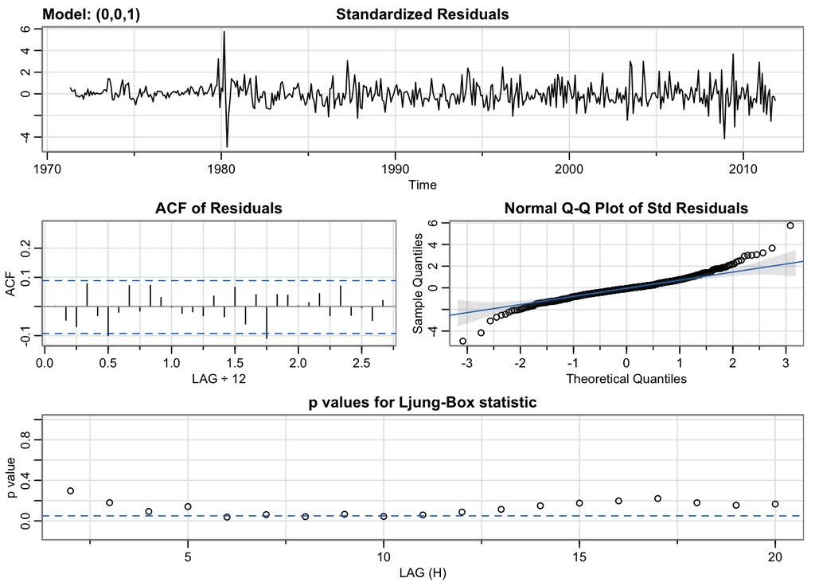

```
## $fit
##
## Call:
## arima(x = xdata, order = c(p, d, q), seasonal = list(order = c(P, D, Q), period = S),
##     xreg = xmean, include.mean = FALSE, transform.pars = trans, fixed = fixed,
##     optim.control = list(trace = trc, REPORT = 1, reltol = tol))
##
## Coefficients:
##          ma1
##       0.4567
## s.e.  0.0384
##
## sigma^2 estimated as 0.0007328:  log likelihood = 1066.58,  aic = -2129.17
##
## $degrees_of_freedom
## [1] 486
##
## $ttable
##     Estimate     SE t.value p.value
## ma1   0.4567 0.0384 11.8955       0
##
## $AIC
## [1] -4.372012
##
## $AICc
## [1] -4.371995
##
## $BIC
## [1] -4.354811
```

```r
(ma1 <- sarima(new_morg, p=0, d=0, q=1, no.constant=TRUE))
```